# Forecasting exercise performance from wearable tech data using machine learning and cross validation

Matthew Malishev

### The compiled HTML report is found at this link: https://darwinanddavis.github.io/data_science_specialisation/ml/ass/malishev_ml_ass.html

Date: 2020-05-29  
R version: 3.5.0

R session info

```r
params$session
```

## Overview

This project uses learning models to predict how well participants with wearable fit tech performed exercises. The aim is to use these performance data to improve data quality for both user and future applications of wearable tech.

A series of learning models were applied to test how well the training data could predict the four incorrect exercise movements in the test data.

```r
require(caret)
require(dplyr)
require(readr)
require(here)
require(randomForest)
require(rattle)
```

Read in the data

Visualise the data

```r
training_data %>% names
```

```
  [1] "X1"                       "user_name"                "raw_timestamp_part_1"
  [4] "raw_timestamp_part_2"     "cvtd_timestamp"           "new_window"
  [7] "num_window"               "roll_belt"                "pitch_belt"
 [10] "yaw_belt"                 "total_accel_belt"         "kurtosis_roll_belt"
 [13] "kurtosis_picth_belt"      "kurtosis_yaw_belt"        "skewness_roll_belt"
 [16] "skewness_roll_belt.1"     "skewness_yaw_belt"        "max_roll_belt"
 [19] "max_picth_belt"           "max_yaw_belt"             "min_roll_belt"
 [22] "min_pitch_belt"           "min_yaw_belt"             "amplitude_roll_belt"
 [25] "amplitude_pitch_belt"     "amplitude_yaw_belt"       "var_total_accel_belt"
 [28] "avg_roll_belt"            "stddev_roll_belt"         "var_roll_belt"
 [31] "avg_pitch_belt"           "stddev_pitch_belt"        "var_pitch_belt"
 [34] "avg_yaw_belt"             "stddev_yaw_belt"          "var_yaw_belt"
 [37] "gyros_belt_x"             "gyros_belt_y"             "gyros_belt_z"
 [40] "accel_belt_x"             "accel_belt_y"             "accel_belt_z"
 [43] "magnet_belt_x"            "magnet_belt_y"            "magnet_belt_z"
```

[output cut: 39 more lines]

After reading in the data, remove all the variables with zero variance

```r
nzvar <- nearZeroVar(training_data)
training_data <- training_data[, -nzvar]
testing_data <- testing_data[, -nzvar]
dim(training_data)
```

```
[1] 19622   119
```

```r
dim(testing_data)
```

```
[1]  20 119
```

### Split the training and testing data

Set the seed and remove NAs from the data that will confound the predictions. Set the threshold to 90% to make it interesting.

```r
set.seed(12)
# remove nas
rmna <- sapply(training_data, function(x) mean(is.na(x))) > 0.9
training_data <- training_data[, rmna == F]
testing_data <- testing_data[, rmna == F]
```

We also need to remove the unneeded variables that won’t be part of the predictions, then we can split the data into training and testing sets.

```r
training_data <- training_data[, -c(1:7)]  # remove unneeded variables
testing_data <- testing_data[, -c(1:7)]

inTrain = createDataPartition(y = training_data$classe, p = 0.5, list = F)
training = training_data[inTrain, ]
testing = training_data[-inTrain, ]

colnames(training) <- make.names(colnames(training))
colnames(testing) <- make.names(colnames(testing))
training$classe <- factor(as.character(training$classe))
testing$classe <- factor(as.character(testing$classe))
```

## Model 1: Classification tree

First, the training model was built from the training dataset for each of the exercise variables of interest for a user.

The idea then is to classify the data by building a classification tree. We use the training data to train the model for the classification, then test it against the testing data for the variables of interest.

```r
mod1 <- train(classe ~ ., method = "rpart", data = training)
mod1fin <- mod1$finalModel
```

We can see how much variation the classification captures by summarising the final model prediction on the training data, then plotting the classification tree.

```r
mod1fin
```

```
n= 9812

node), split, n, loss, yval, (yprob)
      * denotes terminal node

 1) root 9812 7022 A (0.28 0.19 0.17 0.16 0.18)
   2) pitch_forearm< -33.95 743    5 A (0.99 0.0067 0 0 0) *
   3) pitch_forearm>=-33.95 9069 7017 A (0.23 0.21 0.19 0.18 0.2)
     6) accel_belt_z>=-187.5 8561 6512 A (0.24 0.22 0.2 0.19 0.15)
      12) magnet_dumbbell_y< 439.5 7155 5151 A (0.28 0.17 0.23 0.18 0.13)
        24) roll_forearm< 122.5 4475 2679 A (0.4 0.17 0.18 0.16 0.092) *
        25) roll_forearm>=122.5 2680 1816 C (0.078 0.18 0.32 0.23 0.2)
          50) magnet_dumbbell_y< 291.5 1582  835 C (0.092 0.13 0.47 0.15 0.16) *
          51) magnet_dumbbell_y>=291.5 1098  724 D (0.056 0.25 0.11 0.34 0.25) *
      13) magnet_dumbbell_y>=439.5 1406  748 B (0.032 0.47 0.035 0.2 0.26) *
     7) accel_belt_z< -187.5 508    4 E (0.0059 0.002 0 0 0.99) *
```

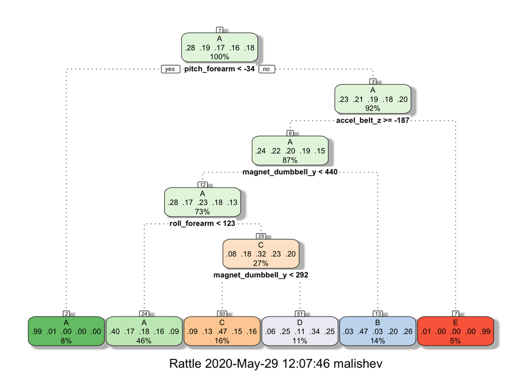

```r
require(rattle)
fancyRpartPlot(mod1fin)
```

Then we predict the new values for the testing data using the trained classification model and get the accuracy.

```r
# predict against testing data
pred1 <- predict(mod1, testing)
# get accuracy
sum(pred1 == testing$classe)/length(pred1)
```

```
[1] 0.4902141
```

## Model 2: Bagging

We can test another model to see if it performs better, such as a boottrapping with aggregation, i.e. bagging.

The model works by averaging complicated models together to get a smoother model fit that gives a balance between potential bias and variance in model fit.

```r
mod2 <- train(classe ~ ., method = "treebag", coob = T, keepX = T, data = training)
mod2fin <- mod2$finalModel
# prediction for bagging method
pred2 <- predict(mod2, testing)
sum(pred2 == testing$classe)/length(pred2)
```

```
[1] 0.9784913
```

## Model 3: Boosting (GBM)

Finally, we test another boosting method for the predictors (GBM model).

```r
require(randomForest)
mod3 <- train(classe ~ ., method = "gbm", verbose = F, data = training)
mod3fin <- mod3$finalModel
pred3 <- predict(mod3, testing)
confusionMatrix(pred3, testing$classe)
```

```
Confusion Matrix and Statistics

          Reference
Prediction    A    B    C    D    E
         A 2750   58    0    2    8
         B   28 1762   54    6   21
         C    6   56 1624   29   11
         D    5    9   28 1562   29
         E    1   13    5    9 1734

Overall Statistics

               Accuracy : 0.9615
                 95% CI : (0.9575, 0.9652)
    No Information Rate : 0.2844
    P-Value [Acc > NIR] : < 2.2e-16

                  Kappa : 0.9513

 Mcnemar's Test P-Value : 3.095e-05

Statistics by Class:

                     Class: A Class: B Class: C Class: D Class: E
Sensitivity            0.9857   0.9283   0.9492   0.9714   0.9617
Specificity            0.9903   0.9862   0.9874   0.9913   0.9965
Pos Pred Value         0.9759   0.9417   0.9409   0.9565   0.9841
Neg Pred Value         0.9943   0.9829   0.9892   0.9944   0.9914
Prevalence             0.2844   0.1935   0.1744   0.1639   0.1838
Detection Rate         0.2803   0.1796   0.1655   0.1592   0.1768
Detection Prevalence   0.2873   0.1907   0.1759   0.1665   0.1796
Balanced Accuracy      0.9880   0.9573   0.9683   0.9814   0.9791
```

```r
sum(pred3 == testing$classe)/length(pred3)
```

```
[1] 0.9614679
```

## Combined model

By combining the model predictions, we can cross validate how well they perform on the testing data using a GAM method.

```r
pred_df <- data.frame("Classification tree" = pred1,
                    "Bagging" = pred2,
                    "GBM" = pred3,
                    classe=testing$classe)
modcom <- train(classe ~.,
                method="gam", # apply a gam method for predicting all models
                data=pred_df)
modcomfin <- modcom$finalModel # get final final
modcom_pred <- predict(modcom,pred_df) # test against testing data

# run diagnostics
table(modcom_pred,testing$classe)
```

```
modcom_pred    A    B    C    D    E
          A 2757   23    0    1    1
          B   33 1875 1711 1607 1802
          C    0    0    0    0    0
          D    0    0    0    0    0
          E    0    0    0    0    0
```

```r
confusionMatrix(table(modcom_pred,testing$classe))
```

```
Confusion Matrix and Statistics


modcom_pred    A    B    C    D    E
          A 2757   23    0    1    1
          B   33 1875 1711 1607 1802
          C    0    0    0    0    0
          D    0    0    0    0    0
          E    0    0    0    0    0

Overall Statistics

               Accuracy : 0.4722
                 95% CI : (0.4623, 0.4821)
    No Information Rate : 0.2844
    P-Value [Acc > NIR] : < 2.2e-16

                  Kappa : 0.3239

 Mcnemar's Test P-Value : NA

Statistics by Class:

                     Class: A Class: B Class: C Class: D Class: E
Sensitivity            0.9882   0.9879   0.0000   0.0000   0.0000
Specificity            0.9964   0.3487   1.0000   1.0000   1.0000
Pos Pred Value         0.9910   0.2668      NaN      NaN      NaN
Neg Pred Value         0.9953   0.9917   0.8256   0.8361   0.8162
Prevalence             0.2844   0.1935   0.1744   0.1639   0.1838
Detection Rate         0.2810   0.1911   0.0000   0.0000   0.0000
Detection Prevalence   0.2836   0.7164   0.0000   0.0000   0.0000
Balanced Accuracy      0.9923   0.6683   0.5000   0.5000   0.5000
```

## Conclusion

The bagging model outperforms both other methods due to it’s higher accuracy, so we choose this model as the final model for the testing dataset.

```r
data.frame(model = c("Classification tree", "Bagging", "GBM", "GAM"), accuracy = c(sum(pred1 == testing$classe)/length(pred1),
    sum(pred2 == testing$classe)/length(pred2), sum(pred3 == testing$classe)/length(pred3), sum(modcom_pred ==
        testing$classe)/length(modcom_pred)))
```

```
                model  accuracy
1 Classification tree 0.4902141
2             Bagging 0.9784913
3                 GBM 0.9614679
4                 GAM 0.4721713
```

With our selected model, we can test how well it performs on the testing data set.

```r
pred_final <- predict(mod2, testing_data)
pred_final[1:20]
```

```
 [1] B A B A A E D B A A B C B A E E A B B B
Levels: A B C D E
```